# Methods of Empirical Finance

## Seminar (UE)

### Christoph Huber

### University of Innsbruck

#### Master in Banking and Finance

### Winter term 2019/20 (this version: 2019-12-03)

# (Non)Parametric Statistical Tests

### Methods of Empirical Finance

<footer></footer>

# (Non)Parametric Statistical Tests

### Parametric vs. Non-parametric tests

Parametric:

- based on _parametric_ families of _probability distributions_

- rely on assumptions that the data are drawn from a given prob. distribution
  (e.g. the underlying population is normally distributed)

Non-parametric:

- _distribution-free_ test statistics

- do _not_ rely on assumptions about the data's prob. distribution

<footer></footer>

# (Non)Parametric Statistical Tests

### Parametric vs. Non-parametric tests

When should I use a parametric test?

When should I use a _non_-parametric test?

- __scale/level of measurement__ ?

non-metric (nominal, ordinal) vs. metric (interval, ratio) data

- __the distribution of the data__ ?

normally distributed vs. non-normally distributed

<footer></footer>

# (Non)Parametric Statistical Tests

### Parametric vs. Non-parametric tests

We mostly use ...

... __parametric__ test statistics if ...

- the level of measurement is _metric_ (interval or ratio),

- the population is _normally distributed_,

- the sample size is _large_

... __non-parametric__ test statistics if ...

- the level of measurement is _non-metric_ (nominal or ordinal),

- the population is _non-normally distributed_,

- the sample size is _small_

<footer></footer>

# (Non)Parametric Statistical Tests

As the appropriate test statistic depends on the data's level of measure,
its (assumed) distribution, as well as its sample size, ...

... it makes sense to always get an overview about the data first,

... and &mdash; if you want to use parametric test statistics, in particular
&mdash;, to test for normality of your data

<footer></footer>

# Testing for Normality

<footer></footer>

# Testing for Normality

### Some useful functions for distributions in _R_

For normal distributions:

```r
dnorm(x=0, mean=0, sd=1)    # prob. density function (pdf)
```

```
## [1] 0.3989423
```

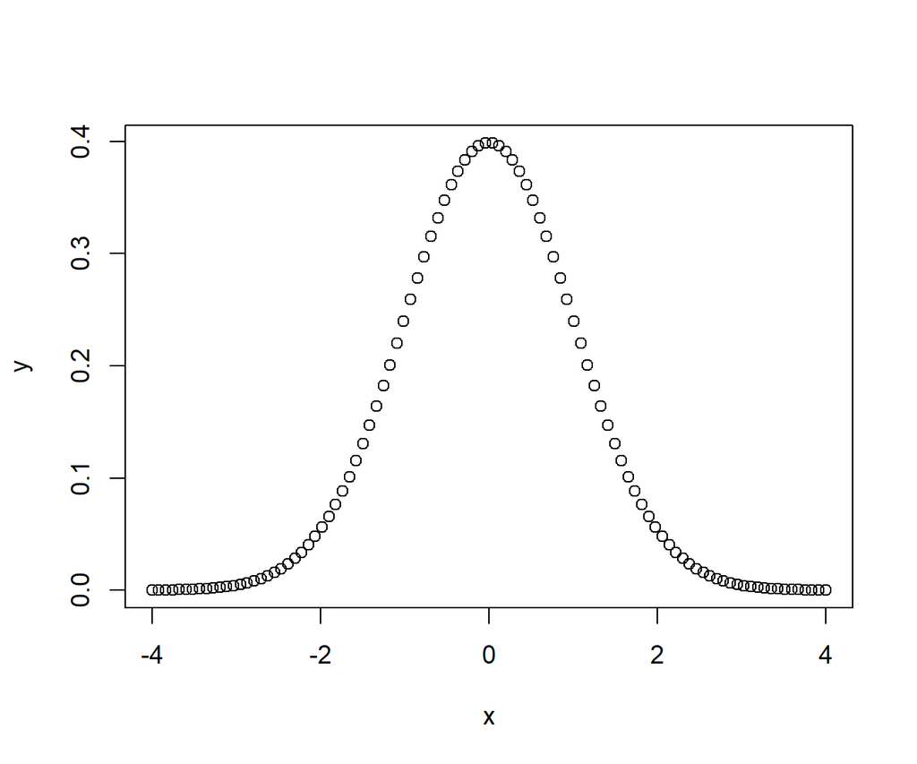

```r
x <- seq(-4, 4, length=100)
y <- dnorm(x)
plot(x, y)
```

<footer></footer>

# Testing for Normality

### Some useful functions for distributions in _R_

```r
pnorm(74, mean=70, sd=2)    # cumulative density function (cdf)
```

```
## [1] 0.9772499
```

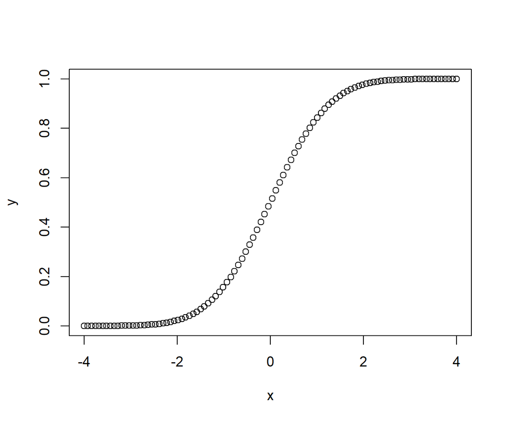

```r
y <- pnorm(x)
plot(x, y)
```

<footer></footer>

# Testing for Normality

### Some useful functions for distributions in _R_

```r
# e.g. find the Z-score of the 99th quantile of the standard normal distribution
qnorm(.99, mean=0, sd=1)    # (inverse cumulative density function (cdf))
```

```
## [1] 2.326348
```

```r
rnorm(5, mean = 10, sd = 2)    # generates normally distributed random variables
```

```
## [1] 10.858815  7.864668  6.219411 10.179098  7.397888
```

See [here](https://www.statology.org/a-guide-to-dnorm-pnorm-rnorm-and-qnorm-in-r/), for example.

Similarly, these functions are available for most other popular probability distributions.

<footer></footer>

# Testing for Normality

### 'Descriptive': Histograms and normal density

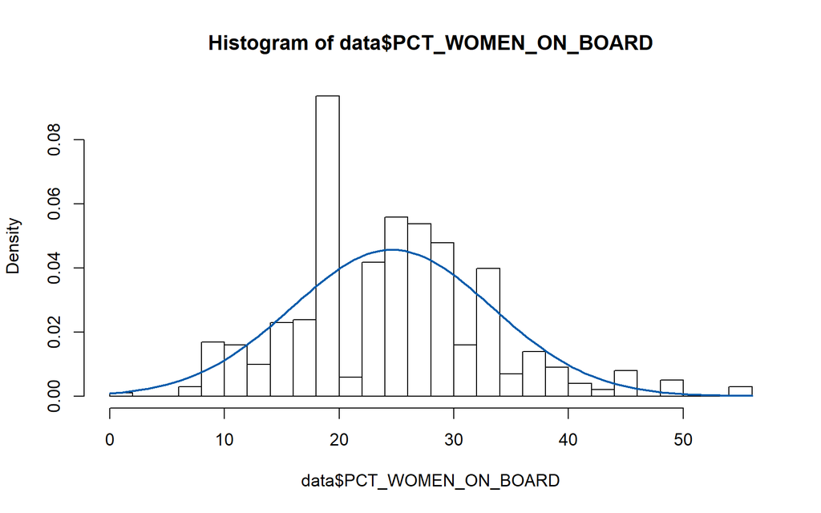

```r
hist(data$PCT_WOMEN_ON_BOARD, prob = TRUE, breaks = 20)
curve(dnorm(x,
            mean = mean(data$PCT_WOMEN_ON_BOARD, na.rm = TRUE),
            sd = sd(data$PCT_WOMEN_ON_BOARD, na.rm = TRUE)),
      col = ubluelight, lwd = 2,
      add = TRUE, yaxt="n")
```

<footer></footer>

# Testing for Normality

### 'Descriptive': QQ plots

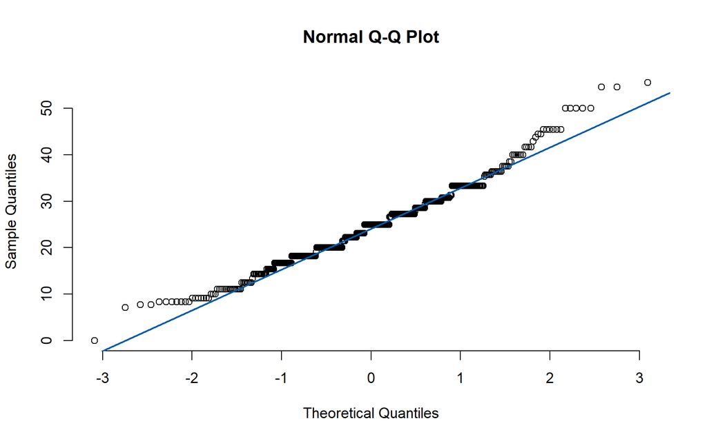

```r
qqnorm(data$PCT_WOMEN_ON_BOARD, frame = FALSE)
qqline(data$PCT_WOMEN_ON_BOARD, col = ubluelight, lwd = 2)
```

<footer></footer>

# Testing for Normality

### Kolmogorov-Smirnov Goodness-of-Fit Test

> tests whether the empirical distribution function of the sample and the
> cumulative distribution function of some reference distribution are equal in
> location and shape

- __nature of independent variable(s):__ no independent variables, 1 population

- __scale of dependent variable:__ ordinal or interval

- __hypothesis:__

- `\(H_0\)`: `\(F(x) = F_0(x)\)` for all values of `\(x\)`

- `\(H_1\)`: `\(F(x) \neq F_0(x)\)` or `\(F(x) > F_0(x)\)` or `\(F(x) < F_0(x)\)`

<footer></footer>

# Testing for Normality

### Kolmogorov-Smirnov Goodness-of-Fit Test &mdash; Example

```r
ks.test(data$PCT_WOMEN_ON_BOARD,
        "pnorm",
        mean = mean(data$PCT_WOMEN_ON_BOARD, na.rm=TRUE),
        sd = sd(data$PCT_WOMEN_ON_BOARD, na.rm=TRUE))
```

```
##
## 	One-sample Kolmogorov-Smirnov test
##
## data:  data$PCT_WOMEN_ON_BOARD
## D = 0.075887, p-value = 0.006166
## alternative hypothesis: two-sided
```

<footer></footer>

# Testing for Normality

### Shapiro-Wilk Test

> tests whether a sample `\(x_1, ..., x_n\)` is drawn from a
> normally distributed population

- __nature of independent variable(s):__ no independent variables, 1 population

- __scale of dependent variable:__ ordinal or interval

- __hypothesis:__

- `\(H_0\)`: `\(F(x) = F_0(x)\)` for all values of `\(x\)`

- `\(H_1\)`: `\(F(x) \neq F_0(x)\)` or `\(F(x) > F_0(x)\)` or `\(F(x) < F_0(x)\)`

<footer></footer>

# Testing for Normality

### Shapiro-Wilk Test &mdash; Example

```r
shapiro.test(data$CHG_NET_YTD)
```

```
##
## 	Shapiro-Wilk normality test
##
## data:  data$CHG_NET_YTD
## W = 0.37452, p-value < 2.2e-16
```

<footer></footer>

# One-Sample Test Statistics

<footer></footer>

# One-Sample Test Statistics

### `\(\chi^2\)` Goodness of Fit Test

> tests whether the observed proportions for a categorical variable of a single population
> differ significantly from hypothesized (expected) proportions

- __nature of independent variable(s):__ no independent variables, 1 population

- __scale of dependent variable:__ categorical/nominal

- __hypothesis:__

- `\(H_0\)`: `\(p_i = p_{i,0} \forall i \in [1, . . . , k]\)`

- `\(H_1\)`: `\(p_i \neq p_{i,0} \forall i \in [1, . . . , k]\)` ('The observed proportions ( `\(p_{i,0}\)` ) differ from hypothesized (expected) proportions ( `\(p_{i}\)` ).')

<footer></footer>

# One-Sample Test Statistics

### `\(\chi^2\)` Goodness of Fit Test &mdash; Example

- We use the data from `sp500_data.csv`.

- Test _whether the proportion of companies in the S&P 500 with a
  female CEO is different from 20%_.

```r
females <- sum(data$FEMALE_CEO_OR_EQUIVALENT, na.rm=TRUE)
total <- sum(!is.na(data$FEMALE_CEO_OR_EQUIVALENT))

x <- c(total - females, females)
x
```

```
## [1] 479  23
```

```r
chisq.test(x, p = c(0.8, 0.2))
```

```
##
## 	Chi-squared test for given probabilities
##
## data:  x
## X-squared = 74.586, df = 1, p-value < 2.2e-16
```

<footer></footer>

# One-Sample Test Statistics

### One-Sample Wilcoxon Signed Rank Test

> tests whether the population from which the data were sampled is symmetric
> or not about the default value

- __nature of independent variable(s):__ no independent variables, 1 population

- __scale of dependent variable:__ ordinal or interval

<footer></footer>

# One-Sample Test Statistics

### One-Sample Wilcoxon Signed Rank Test &mdash; Example

- Test _whether the median yearly net change in prices is different from 0_.
  I.e., whether the population from which the data were sampled is centered
  around 0.

```r
wilcox.test(data$CHG_NET_YTD, mu = 0)
```

```
##
## 	Wilcoxon signed rank test with continuity correction
##
## data:  data$CHG_NET_YTD
## V = 115647, p-value < 2.2e-16
## alternative hypothesis: true location is not equal to 0
```

<footer></footer>

# One-Sample Test Statistics

### One-Sample `\(t\)`-Test

> evaluates whether the sample mean ( `\(\mu\)` ) of a test variable significantly differs from
> a constant test value `\(μ_0\)`

- __nature of independent variable(s):__ no independent variables, 1 population

- __scale of dependent variable:__ interval or ratio

- __hypothesis:__

- `\(H_0\)`: `\(\mu = \mu_0\)`

- `\(H_1\)`: `\(\mu \neq \mu_0\)` or `\(\mu > \mu_0\)` or `\(\mu < \mu_0\)` ('The sample mean `\(\mu\)` significantly differs from the constant test value `\(\mu_0\)`.')

- __assumptions:__

- the observations in the sample are independent of each other

- the observations follow a normal distribution with mean `\(\mu\)` and variance `\(\sigma^2\)`

<footer></footer>

# One-Sample Test Statistics

### One-Sample `\(t\)`-Test &mdash; Example

- Test _whether the mean yearly net change in prices is different from 0_.

```r
summary(data$CHG_NET_YTD)
```

```
##     Min.  1st Qu.   Median     Mean  3rd Qu.     Max.     NA's
## -146.950    5.395   15.170   28.076   33.490 1215.650        6
```

```r
t.test(data$CHG_NET_YTD, mu = 0)
```

```
##
## 	One Sample t-test
##
## data:  data$CHG_NET_YTD
## t = 9.1499, df = 498, p-value < 2.2e-16
## alternative hypothesis: true mean is not equal to 0
## 95 percent confidence interval:
##  22.04771 34.10538
## sample estimates:
## mean of x
##  28.07655
```

__But__: Do our assumptions hold? Is the data _normally distributed_?

<footer></footer>

# Unpaired Two-Sample Test Statistics

<footer></footer>

# Unpaired Two-Sample Test Statistics

### Pearson’s `\(\chi^2\)` Test for `\(r \times\)` c tables

> tests whether there is a relationship between two categorical variables (or tests
whether or not the `\(r\)` samples are homogeneous regarding the proportion of observations
in each of the `\(c\)` categories; `\(\chi^2\)` test for homogeneity)

- __nature of independent variable(s):__ 1 independent variables with 2 levels (independent groups)

- __scale of dependent variable:__ categorical/nominal

- __hypothesis:__

- `\(H_0\)`: `\(O_{ij} = E_{ij}\)` for all cells

- `\(H_1\)`: `\(O_{ij} \neq E_{ij}\)` for at least one cell

<footer></footer>

# Unpaired Two-Sample Test Statistics

### Pearson’s `\(\chi^2\)` Test for `\(r \times\)` c tables &mdash; Example

- Test whether there is a relationship between the company's industry group and
  the percentage of women on its board.

```r
chisq.test(data$INDUSTRY_GROUP, data$PCT_WOMEN_ON_BOARD)
```

```
##
## 	Pearson's Chi-squared test
##
## data:  data$INDUSTRY_GROUP and data$PCT_WOMEN_ON_BOARD
## X-squared = 2532.7, df = 2419, p-value = 0.05262
```

<footer></footer>

# Unpaired Two-Sample Test Statistics

### Wilcoxon Rank Sum Test (Mann-Whitney `\(U\)`-test)

> tests whether two independent samples are drawn from the same population

- __nature of independent variable(s):__ 1 independent variables with 2 levels (independent groups)

- __scale of dependent variable:__ ordinal or interval

<footer></footer>

# Unpaired Two-Sample Test Statistics

### Wilcoxon Rank Sum Test &mdash; Example

- Test whether the percentage of women on the board of financial companies are
  drawn from the same distribution as the pct. of women on board of industrial
  companies.

```r
wilcox.test(PCT_WOMEN_ON_BOARD ~ INDUSTRY_SECTOR,
            data = data %>% filter(INDUSTRY_SECTOR == "Financial" | INDUSTRY_SECTOR == "Industrial"))
```

```
##
## 	Wilcoxon rank sum test with continuity correction
##
## data:  PCT_WOMEN_ON_BOARD by INDUSTRY_SECTOR
## W = 3877, p-value = 0.04192
## alternative hypothesis: true location shift is not equal to 0
```

<footer></footer>

# Unpaired Two-Sample Test Statistics

### Kolmogorov-Smirnov Test

> tests whether two samples are drawn from the same distribution, or,
> more precisely, whether two independent empirical distributions are equal in
> location and shape

- __nature of independent variable(s):__ 1 independent variables with 2 levels (independent groups)

- __scale of dependent variable:__ ordinal or interval

<footer></footer>

# Unpaired Two-Sample Test Statistics

### Kolmogorov-Smirnov Test

- Test whether the percentage of women on the board of financial companies are
  drawn from the same distribution as the pct. of women on board of industrial
  companies or &mdash; more precisely &mdash; whether the the
  empirical distributions are equal in location and shape.

```r
financial <- data %>% filter(INDUSTRY_SECTOR == "Financial") %>% .$PCT_WOMEN_ON_BOARD
industrial <- data %>% filter(INDUSTRY_SECTOR == "Industrial") %>% .$PCT_WOMEN_ON_BOARD

ks.test(financial, industrial)
```

```
##
## 	Two-sample Kolmogorov-Smirnov test
##
## data:  financial and industrial
## D = 0.23232, p-value = 0.02783
## alternative hypothesis: two-sided
```

<footer></footer>

# Unpaired Two-Sample Test Statistics

### Independent Sample `\(t\)`-Test

> evaluates whether the sample means ( `\(\mu_1\)` and `\(\mu_2\)` ) of two independent
> variables significantly differ

- __nature of independent variable(s):__ 1 independent variables with 2 levels (independent groups)

- __scale of dependent variable:__ interval or ratio

- __hypothesis:__

- `\(H_0\)`: `\(\mu_1 = \mu_2\)`

- `\(H_1\)`: `\(\mu_1 \neq \mu_2\)` or `\(\mu_1 > \mu_2\)` or `\(\mu_1 < \mu_2\)`

- __assumptions:__

- all observations from both groups are independent of each other

- the observations follow a normal distribution with mean `\(\mu\)` and variance `\(\sigma^2\)`

- the two independent samples have the same standard deviation, otherwise
    Welch’s approximation should be applied

<footer></footer>

# Unpaired Two-Sample Test Statistics

### Independent Sample `\(t\)`-Test &mdash; Example

- Test whether the mean percentage of woman is different in financial companies
  compared to industrial companies.

```r
financial <- data %>% filter(INDUSTRY_SECTOR == "Financial") %>% .$PCT_WOMEN_ON_BOARD
industrial <- data %>% filter(INDUSTRY_SECTOR == "Industrial") %>% .$PCT_WOMEN_ON_BOARD

t.test(financial, industrial, var.equal=TRUE)
```

```
##
## 	Two Sample t-test
##
## data:  financial and industrial
## t = 2.0421, df = 163, p-value = 0.04275
## alternative hypothesis: true difference in means is not equal to 0
## 95 percent confidence interval:
##  0.07825703 4.65716398
## sample estimates:
## mean of x mean of y
##  25.40932  23.04161
```

<footer></footer>

# Unpaired Two-Sample Test Statistics

### Independent Sample `\(t\)`-Test &mdash; Example

- What if the two samples have different `\(\sigma\)`s?

```r
t.test(financial, industrial, var.equal=FALSE)
```

```
##
## 	Welch Two Sample t-test
##
## data:  financial and industrial
## t = 2.0669, df = 145.08, p-value = 0.04052
## alternative hypothesis: true difference in means is not equal to 0
## 95 percent confidence interval:
##  0.1036396 4.6317814
## sample estimates:
## mean of x mean of y
##  25.40932  23.04161
```

<footer></footer>

# Paired Two-Sample Test Statistics

<footer></footer>

# Paired Two-Sample Test Statistics

### Wilcoxon Signed Rank Test

> tests whether two _dependent_ samples represent two different populations or
> whether the two _dependent_ samples are drawn from the same population

- __nature of independent variable(s):__ 1 independent variables with 2 levels (_dependent_ groups)

- __scale of dependent variable:__ ordinal or interval

- __assumptions:__

- the data are paired and come from the same population

- each pair is chosen randomly and independently

<footer></footer>

# Paired Two-Sample Test Statistics

### Wilcoxon Signed Rank Test &mdash; Example

- Test whether the percentage of women on the board of financial companies
  in 2019 are
  drawn from the same distribution as the pct. of women on board of financial
  companies in 2014.

`wilcox.test()`

<footer></footer>

# Paired Two-Sample Test Statistics

### Dependent `\(t\)`-Test for Paired Samples

- __nature of independent variable(s):__ 1 independent variables with 2 levels (_dependent_ groups)

- __scale of dependent variable:__ interval or ratio

- __hypothesis:__

- `\(H_0\)`: `\(\mu = \mu_0\)`

- `\(H_1\)`: `\(\mu \neq \mu_0\)` or `\(\mu > \mu_0\)` or `\(\mu < \mu_0\)`

- __assumptions:__

- the observations follow a normal distribution with mean `\(\mu\)` and variance `\(\sigma^2\)`

- the two samples have the same standard deviation (homogeneity of variance)

<footer></footer>

# Paired Two-Sample Test Statistics

### Dependent `\(t\)`-Test for Paired Samples

- Test whether the mean percentage of women on the board of financial companies
  in 2019 is different to the mean pct. of women on board of financial
  companies in 2014.

`t.test()`

<footer></footer>

# `\(n\)`-Sample Generalizations: more than 2 groups

<footer></footer>

# `\(n\)`-Sample Generalizations

### Kruskal-Wallis Test

> tests whether two or more independent samples originate from the same
> distribution, i.e., extends the Mann-Whitney `\(U\)`-test when there are
> _more than_
> _two groups_ (for two groups, both statistics are identical)

- __nature of independent variable(s):__ 1 independent variables with two or more levels (independent groups)

- __scale of dependent variable:__ ordinal or interval

<footer></footer>

# `\(n\)`-Sample Generalizations

### Kruskal-Wallis Test &mdash; Example

- Test whether the percentage of women on the board of companies from different
  industry sectors are drawn from the same distribution.

```r
kruskal.test(PCT_WOMEN_ON_BOARD ~ INDUSTRY_SECTOR,
            data = data)
```

```
##
## 	Kruskal-Wallis rank sum test
##
## data:  PCT_WOMEN_ON_BOARD by INDUSTRY_SECTOR
## Kruskal-Wallis chi-squared = 9.3157, df = 8, p-value = 0.3164
```

<footer></footer>

# `\(n\)`-Sample Generalizations

### Jonkheere-Terpstra Test (Jonkheere’s trend test)

> tests whether three or more independent samples originate from the same
> distribution, (just as the Kruskal-Wallis test)
> but with an _ordered_ alternative hypothesis

- __nature of independent variable(s):__ 1 independent variables with three or more levels (independent groups)

- __scale of dependent variable:__ ordinal or interval

- __hypothesis:__

- `\(H_0\)`: `\(\theta_1 = \theta_2 = ... = \theta_k\)`

- `\(H_1\)`: `\(\theta_1 \leq \theta_2 \leq ... \leq \theta_k\)`

- __assumptions and limitations:__

- all observations from all `\(k\)` groups are independent of each other

- hypothesized ordering of groups’ rank-sums required

<footer></footer>

# `\(n\)`-Sample Generalizations

### Jonkheere-Terpstra Test &mdash; Example

- Test whether the percentage of women on the board of companies from
  financial companies is larger than the percentage in industrial companies,
  which is then larger than the respective percentage in basic materials
  companies.

```r
library(clinfun)
groups <- data %>% filter(INDUSTRY_SECTOR == "Financial" |
                                     INDUSTRY_SECTOR == "Industrial" |
                                     INDUSTRY_SECTOR == "Basic Materials")
groups$INDUSTRY_SECTOR <- factor(groups$INDUSTRY_SECTOR, levels = c("Financial", "Industrial", "Basic Materials"), ordered=TRUE)
jonckheere.test(groups$PCT_WOMEN_ON_BOARD,
                groups$INDUSTRY_SECTOR)
```

```
##
## 	Jonckheere-Terpstra test
##
## data:
## JT = 4237, p-value = 0.1625
## alternative hypothesis: two.sided
```

<footer></footer>

# Permutation Tests

<footer></footer>

# Permutation Tests

Consider the following hypothetical problem:

- Ten subjects have been randomly assigned to one of two treatment conditions
(A or B) and an outcome variable (score) has been recorded.

| Treatment A 	 | Treatment B 	|
|:-------------: |:-------------:	|
| 40          	 | 57          	|
| 57          	 | 64          	|
| 45          	 | 55          	|
| 55          	 | 62          	|
| 58          	 | 65          	|

- First, let's use a parametric approach to compare Treatment A and Treatment B.
  `\(\rightarrow\)` `\(t\)`-test:

- assume normal distributions, independent groups, and equal variances

```r
a <- c(40, 57, 45, 55, 58)
b <- c(57, 64, 55, 62, 65)
t.test(a, b, var.equal = TRUE)
```

```
##
## 	Two Sample t-test
##
## data:  a and b
## t = -2.345, df = 8, p-value = 0.04705
## alternative hypothesis: true difference in means is not equal to 0
## 95 percent confidence interval:
##  -19.0405455  -0.1594545
## sample estimates:
## mean of x mean of y
##      51.0      60.6
```

<footer></footer>

# Permutation Tests

A permutation test takes a different approach: If the two treatments are truly
equivalent, the label (Treatment A or Treatment B) assigned to an observed score is
arbitrary.

1. Calculate the observed t-statistic, as in the parametric approach; call this t0.

2. Place all 10 scores in a single group.

3. Randomly assign five scores to Treatment A and five scores to Treatment B.

4. Calculate and record the new observed t-statistic.

5. Repeat steps 3–4 for every possible way of assigning five scores to Treatment A
and five scores to Treatment B. There are 252 such possible arrangements.

6. Arrange the 252 t-statistics in ascending order. This is the empirical
distribution, based on (or conditioned on) the sample data.

7. If t0 falls outside the middle 95 percent of the empirical distribution, reject the
null hypothesis that the population means for the two treatment groups are
equal at the 0.05 level of significance.

<footer></footer>

# Permutation Tests

- In both the permutation and the parametric approach, the exact same
  `\(t\)`-statistic is calculated.

- In the permutation approach, however, the statistic is compared not to a
  theoretical distribution (e.g. an assumed normal distribution) but to an
  _empirical distribution_ created from
  _permutations of the observed data_.

- If this empirical distribution contains _all possible permutations_ of the
  data, the permutation test is called an 'exact' test.

- If there are too many possible permutations to compute the test statistic
  in appropriate time, we ca use (Monte Carlo) _simulations_.

<footer></footer>

# Permutation Tests

In _R_, we can use the `coin` package to run permutation tests as alternatives
for a number of tests.

```r
library(coin)
```

E.g.

```r
df <- data.frame(value = c(a, b), treatment = c(rep("A", 5), rep("B", 5)))
oneway_test(value ~ treatment, data = df)
```

```
##
## 	Asymptotic Two-Sample Fisher-Pitman Permutation Test
##
## data:  value by treatment (A, B)
## Z = -1.9147, p-value = 0.05553
## alternative hypothesis: true mu is not equal to 0
```

See [here](https://cran.r-project.org/web/packages/coin/vignettes/coin.pdf), for example.

<footer></footer>

# (Non)parametric Correlation Measures

- Parametric: Pearson's `\(\rho\)`

- Non-parametric:

- Spearman rank correlation `\(\rho\)`: i.e., the Pearson correlation coefficient between the ranked variables

- Kendall's `\(\tau\)`: similar to Spearman's `\(\rho\)`; measures _ordinal association_ between two measured quantities

The argumentations for using non-parametric _or_ parametric correlation measures
are very similar to the ones for using non_parametric or parametric test
statistics.

Things to consider are: level of measurement, assumptions about the distribution,
assumptions about a linear or non-linear relationship, etc.

<footer></footer>

# (Non)parametric Correlation Measures

### Pearson's `\(\rho\)`

_Linear_ relation between `PCT__WOMEN_ON_BOARD` and `EQY_BETA`?

```r
cor(data$PCT_WOMEN_ON_BOARD, data$EQY_BETA, use="complete.obs")
```

```
## [1] -0.08745765
```

For confidence intervals and a significance test, use `cor.test()`.

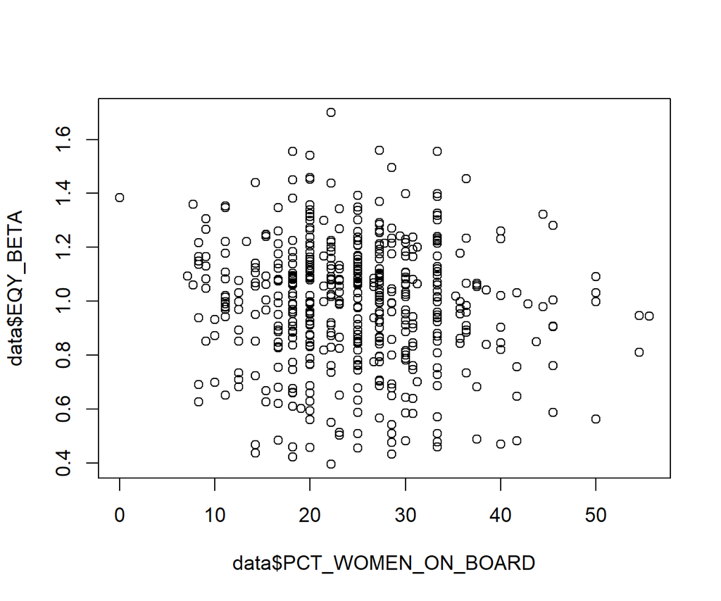

<footer></footer>

# (Non)parametric Correlation Measures

### Spearman rank correlation

```r
cor(data$PCT_WOMEN_ON_BOARD, data$EQY_BETA, use="complete.obs", method="spearman")
```

```
## [1] -0.08065364
```

### Kendall's `\(\tau\)`

```r
cor(data$PCT_WOMEN_ON_BOARD, data$EQY_BETA, use="complete.obs", method="kendall")
```

```
## [1] -0.05475672
```

See [here](https://en.wikipedia.org/wiki/Spearman's_rank_correlation_coefficient) (Wikipedia)
for comparisons between Spearman and Pearson correlations.

# Your turn

- Load the data in `sp500_data.csv` again

- Think about interesting questions and formulate hypotheses you could test
  with these data

- Test your hypothesis(-es) using appropriate tests

- Can you reject the `\(H_0\)`?

- How do you interpret your results?

- Comment on upcoming issues regarding the statistical power, multiple
  hyptheses, normality assumptions, etc.